# Parameter calibration: Bayesian methods

## Problem set

Your task is to modify the code below to estimate the posterior distribution of parameters in Q10 function that was in the likelihood analysis exercise. Use the same data as used in the Q10 likelihood exercise.

```r
library(tidyverse)
library(patchwork)

#Build fake dataset
set.seed(100)
num_data_points <- 200
sd_data <- 0.25
par_true <- c(3, 0.5)
x <- runif(num_data_points, 0, 10)
y_true <- par_true[1] * (x / (x + par_true[2]))
y <- rnorm(length(y_true), mean = y_true, sd = sd_data)
```

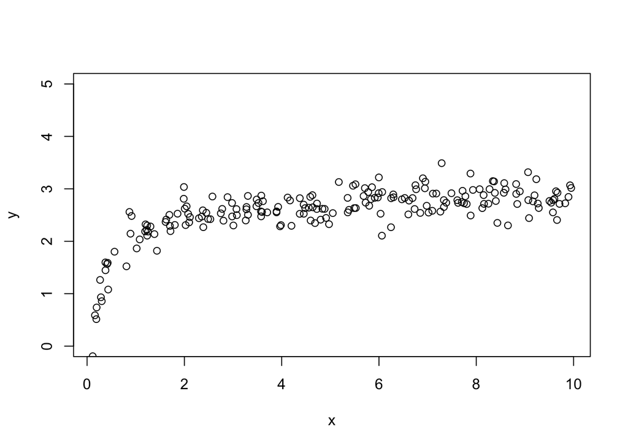

```r
plot(x, y, ylim = c(0, par_true[1] + 2))
```

```r
#Set MCMC Configuration
num_iter <- 2000
num_pars <- 2
jump <- c(0.05, 0.05)

#Initialize chain
pars <- array(NA, dim = c(num_pars, num_iter))
pars[1, 1] <- 2
pars[2, 1] <- 1
log_likelihood_prior_current <- -10000000000

for(i in 2:num_iter){

  #Loop through parameter value

  for(j in 1:num_pars){
      #Randomly select new parameter values
    proposed_pars <- pars[, i - 1]
    proposed_pars[j] <- rnorm(1, mean = pars[j, i - 1], sd = jump[j])

    ##########################
    # PRIORS
    #########################
    #(remember that you multiply probabilities which mean you can add log(probability))
    log_prior <- dunif(proposed_pars[1], min = 0, max = 10, log = TRUE) +
      dunif(proposed_pars[2], min = 0, max = 100, log = TRUE)

    #Likelihood.
    #You could use:
    # pred <- process_model(x, pars = proposed_pars)
    # log_likelihood <- sum(dnorm(new_data, mean = pred, sd = sd_data, log = TRUE)
    # but we are looping here because it transitions well to the next section of the course
    log_likelihood <- rep(NA, length(x))
    pred <- rep(NA, length(x))
    for(m in 1:length(x)){
      ##########################
      # PROCESS MODEL
      #########################
      pred[m] <- proposed_pars[1] * (x[m] / (x[m] + proposed_pars[2]))
      ##########################
      # DATA MODEL
      #########################
      log_likelihood[m] <- dnorm(y[m], mean = pred[m], sd = sd_data, log = TRUE)
    }
    #Remember that you multiply probabilities which mean you can add log(probability)
    #Hence the use of sum
    log_likelihood <- sum(log_likelihood)

    ############################
    ###  PRIOR x LIKELIHOOD
    ############################
    #Combine the prior and likelihood
    #remember that you multiply probabilities which means you can add log(probability)
    log_likelihood_prior_proposed <- log_prior + log_likelihood

    #We want the ratio of new / old but since it is in log space we first
    #take the difference of the logs: log(new/old) = log(new) - log(old)
    # and then take out of log space exp(log(new) - log(old))
    z <- exp(log_likelihood_prior_proposed - log_likelihood_prior_current)

    #Now pick a random number between 0 and 1
    r <- runif(1, min = 0, max = 1)
    #If z > r then accept the new parameters
    #Note: this will always happen if the new parameters are more likely than
    #the old parameters z > 1 means than z is always > r no matter what value of
    #r is chosen.  However it will accept worse parameter sets (P_new is less
    #likely then P_old - i.e., z < 1) in proportion to how much worse it is
    #For example: if z = 0.9 and then any random number drawn by runif that is
    #less than 0.90 will result in accepting the worse values (i.e., the slightly
    #worse values will be accepted a lot of the time).  In contrast, if z = 0.01
    #(i.e., the new parameters are much much worse), then they can still be accepted
    #but much more rarely because random r values of < 0.1 occur more rarely
    if(log(z) > log(r)){
      pars[j, i] <- proposed_pars[j]
      log_likelihood_prior_current <- log_likelihood_prior_proposed
    }else{
      pars[j, i] <- pars[j, i - 1]
      log_likelihood_prior_current <- log_likelihood_prior_current #this calculation isn't necessary but is here to show you the logic
    }
  }
}
```

```r
d <- tibble(iter = 1:num_iter,
            par1 = pars[1, ],
            par2 = pars[2, ]) %>%
  pivot_longer(-iter, values_to = "value", names_to = "parameter")
```

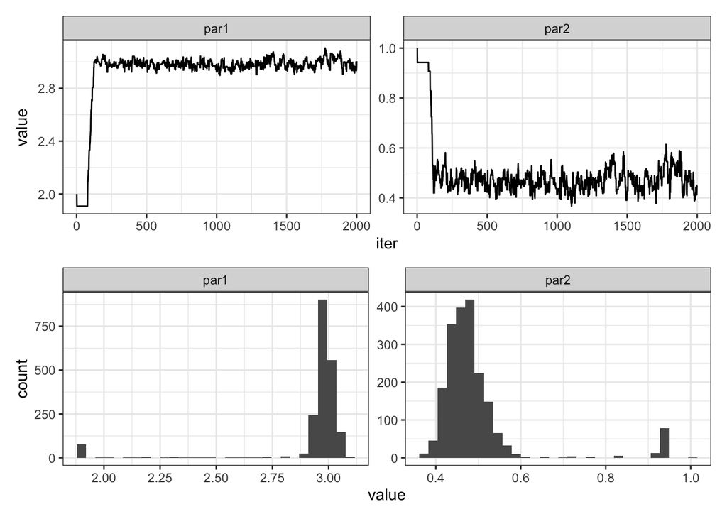

```r
p1 <- ggplot(d, aes(x = iter, y = value)) +
  geom_line() +
  facet_wrap(~parameter, scales = "free") +
  theme_bw()

p2 <- ggplot(d, aes(x = value)) +
  geom_histogram() +
  facet_wrap(~parameter, scales = "free") +
  theme_bw()

p1 / p2
```

```r
#read in dataset
df <- read_csv("https://raw.githubusercontent.com/frec-5174/eco4cast-in-R-book/main/data/soil_respiration_module_data.csv", show_col_types = FALSE)
```

Information about the dataset:

It is a dataset that reports soil respiration, soil temperature, and soil moisture over a year at the University of Michigan Biological Station (from Nave, L.E., N. Bader, and J.L. Klug)

The columns correspond to the following

- doy = Day of Year
- soil_resp: Soil respiration (micromoles CO2 per m2 per second)
- soil_temp: Soil Temp (deg C) soil_moisture: Soil Moisture (%)

**Question 1**: Provide the distribution and parameters describing the distribution for your prior distributions. Justify why you chose the distribution and parameters. (do not spend time looking at the literature for values to use to build prior distribution - just give plausible priors and say why their plausible)

**Answer 1:** With this dataset, I am trying to relate soil temperature and soil respiration, and my three parameters are soil temperature, soil respiration, and standard deviation.

Soil temperature is in degrees C, so a block distribution ranging from 0 to 100 would be a reasonable prior distribution. I know the soil would not reach water’s boiling point, but I do not know the maximum likely temperature of soil to confidently have a maximum prior less than 100 deg C.

Standard deviation can also not be less than zero, but I again do not have an idea of how high standard deviation might max out at. Therefore, I would need another block distribution starting at zero and continuing until infinity.

**Question 2:** Provide plots of your prior distributions.

**Answer 2:**

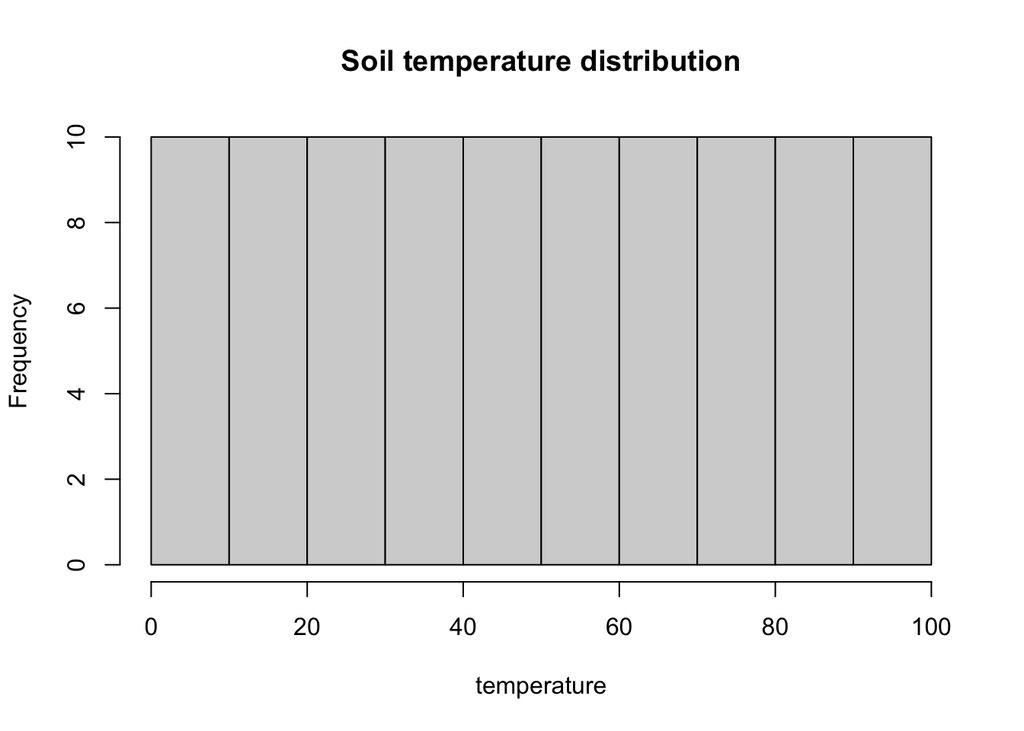

```r
#temperature
prior<-tibble(temperature=c(1:100))
temp.dist<-hist(prior$temperature, main="Soil temperature distribution", xlab = "temperature")
```

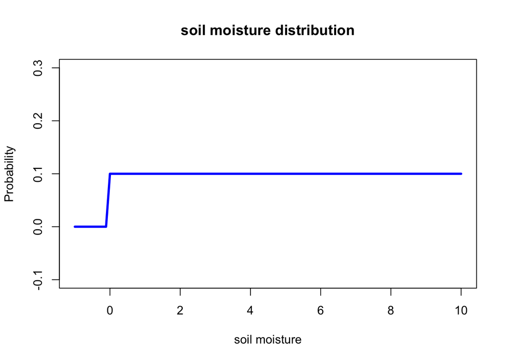

```r
#soil moisture
x <- seq(-1, 10, length=100)
y <- dunif(x, min = 0, max = 10)
moist.dist<-plot(x, y, type = 'l', lwd = 3, ylim = c(-.1, .3), col='blue',
     xlab='soil moisture', ylab='Probability', main='soil moisture distribution')
```

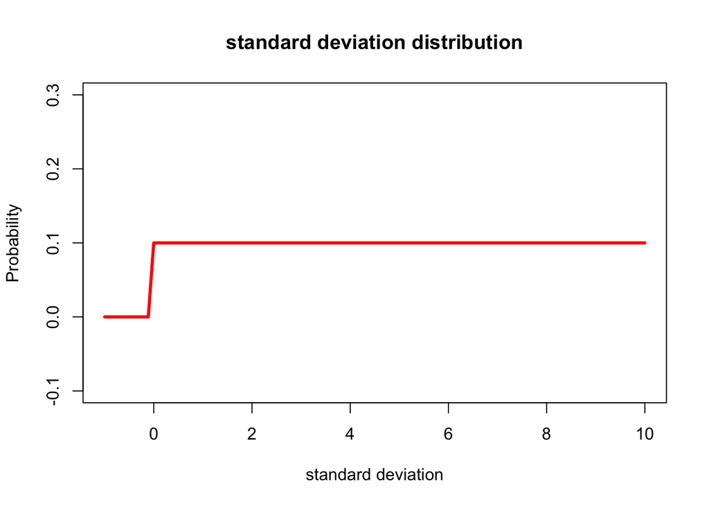

```r
#standard deviation
sd.dist<-plot(x, y, type = 'l', lwd = 3, ylim = c(-.1, .3), col='red',
     xlab='standard deviation', ylab='Probability', main='standard deviation distribution')
```

**Question 3:** Modify the code above to estimate the posterior distribution of your parameters. Put your modified code below.

**Answer 3:**

```r
#Set MCMC Configuration
num_iter <- 1000
num_pars <- 3
jump <- c(0.1, 0.1, 0.1)
accept<-0

#get x and y from data
x<-df$soil_temp
y<-df$soil_resp

#Initialize chain
pars <- array(NA, dim = c(num_pars, num_iter))
#starting parameters using optimized values from likelihood analysis
pars[1, 1] <- 6.7456187
pars[2, 1] <- 2.3493417
pars[3, 1] <- 0.6820145
log_likelihood_prior_current <- -10000000000

for(i in 2:num_iter){

  #Loop through parameter value

  for(j in 1:num_pars){
      #Randomly select new parameter values
    proposed_pars <- pars[, i - 1]
    proposed_pars[j] <- rnorm(1, mean = pars[j, i - 1], sd = jump[j])

    ##########################
    # PRIORS
    #########################
    log_prior <- dunif(proposed_pars[1], min = 0, max = 100, log = TRUE) +
      dunif(proposed_pars[2], min = 0, max = 100, log = TRUE)

    #Likelihood.
    log_likelihood <- rep(NA, length(x))
    pred <- rep(NA, length(x))
    for(m in 1:length(x)){
      ##########################
      # PROCESS MODEL
      #########################
      pred[m] <- proposed_pars[1] * proposed_pars[2]**((x[m]-20)/10)
      ##########################
      # DATA MODEL
      #########################
      log_likelihood[m] <- dnorm(y[m], mean = pred[m], sd = proposed_pars[3], log = TRUE)
    }

    log_likelihood <- sum(log_likelihood)

    ############################
    ###  PRIOR x LIKELIHOOD
    ############################
    #Combine the prior and likelihood
    log_likelihood_prior_proposed <- log_prior + log_likelihood

    #ratio of new / old
    z <- exp(log_likelihood_prior_proposed - log_likelihood_prior_current)

    #pick a random number between 0 and 1
    r <- runif(1, min = 0, max = 1)

    #If z > r then accept the new parameters
    if(log(z) > log(r)){
      pars[j, i] <- proposed_pars[j]
      log_likelihood_prior_current <- log_likelihood_prior_proposed
      accept <- accept + 1
    }else{
      pars[j, i] <- pars[j, i - 1]
      log_likelihood_prior_current <- log_likelihood_prior_current
    }
  }
}

d <- tibble(iter = 1:num_iter,
            par1 = pars[1, ],
            par2 = pars[2, ],
            par3 = pars[3, ]) %>%
  pivot_longer(-iter, values_to = "value", names_to = "parameter")

#examine acceptance rate (goal is 23-45%)
accept / (num_iter * num_pars)
```

```
[1] 0.4163333
```

**Question 4:** Plot the your MCMC chain for all parameters (iteration # will be the x-axis)

**Answer 4:**

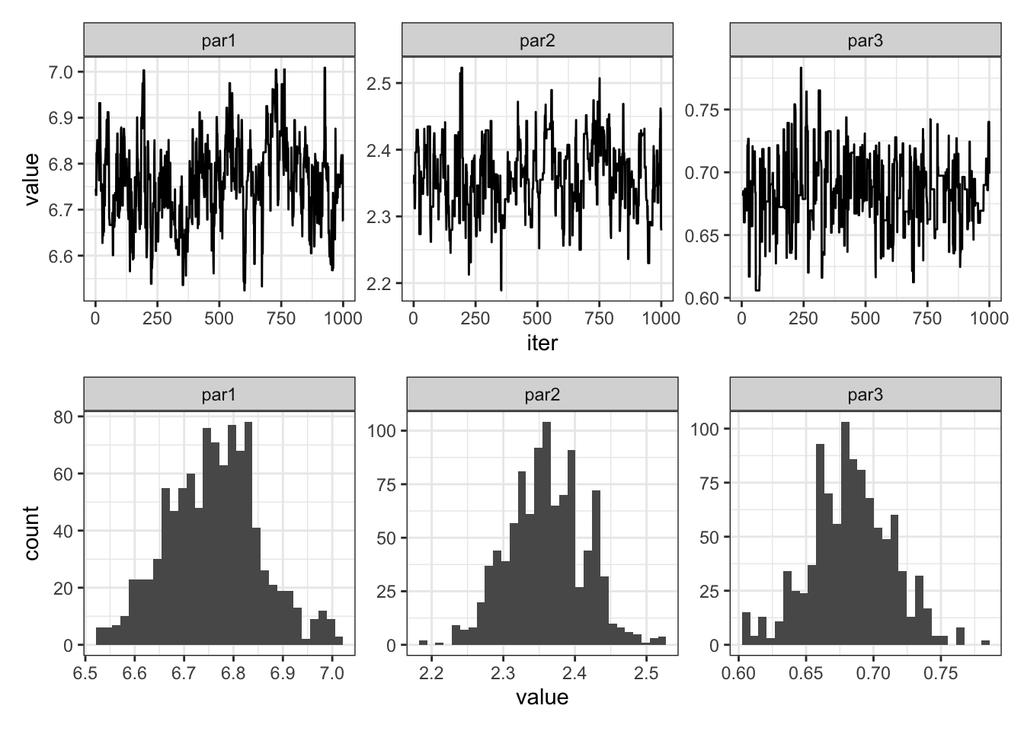

```r
p1 <- ggplot(d, aes(x = iter, y = value)) +
  geom_line() +
  facet_wrap(~parameter, scales = "free") +
  theme_bw()

p2 <- ggplot(d, aes(x = value)) +
  geom_histogram() +
  facet_wrap(~parameter, scales = "free") +
  theme_bw()

p1 / p2
```

**Question 5:** Approximately how many iterations did it take your chain to converge to a straight line with constant variation around the line (i.e., a fuzzy caterpillar). This is the burn-in. If your chain did not converge, modify the `jump` variable for each parameters and/or increase your iterations. You should not need more than 10000 iterations for convergence so running the chain for a long period of time will not fix issues that could be fixed by modifying the `jump` variable. Also, pay attention to the `sd_data` parameter. You should estimate it as a parameter or set it to a reasonable value. If it is too small your chain will fail because the probability of the some of parameters that are explored functionally zero.

**Answer 5:** Because I used the starting parameters from the likelihood problem set, my chain converged *very* quickly. There was really no burn-in, especially because values both above and below my starting values were regularly accepted in the z>r test for all parameters. My starting parameters were within one jump step of the mean parameter values.

**Question 6:** Remove the iterations between 1 and your burn-in number and plot the histograms for your parameters.

**Answer 6:**

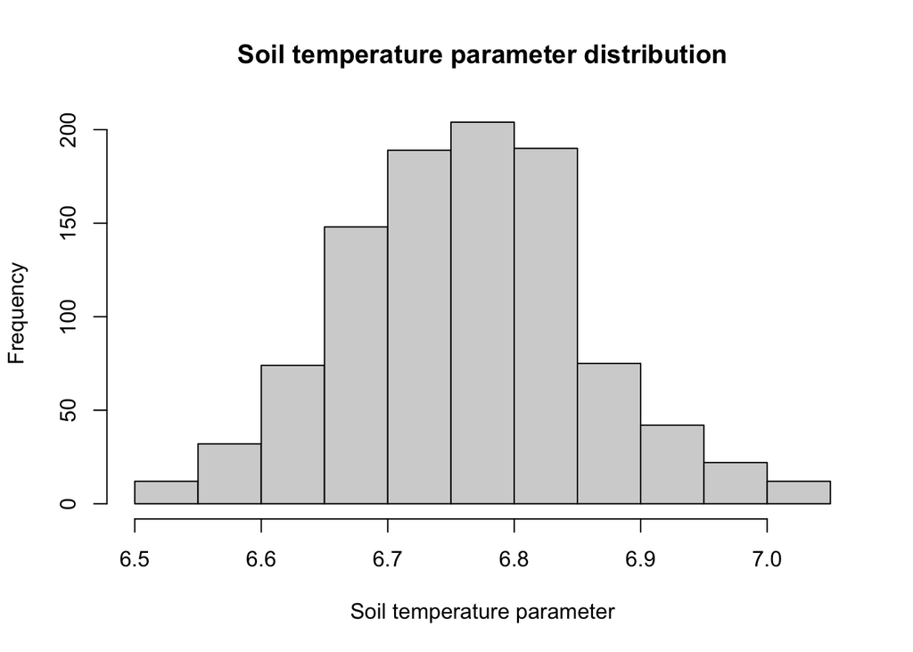

```r
nburn<-1 #because I had no burn-in
d_MCMC <- tibble(iter = nburn:num_iter,
            par1 = pars[1, nburn:num_iter],
            par2 = pars[2, nburn:num_iter],
            par3 = pars[3, nburn:num_iter])

hist(d_MCMC$par1, main="Soil temperature parameter distribution", xlab = "Soil temperature parameter")
```

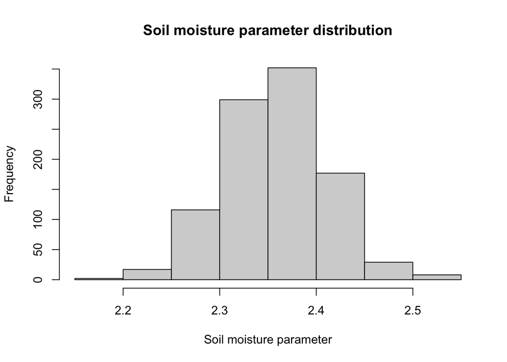

```r
hist(d_MCMC$par2, main="Soil moisture parameter distribution", xlab = "Soil moisture parameter")
```

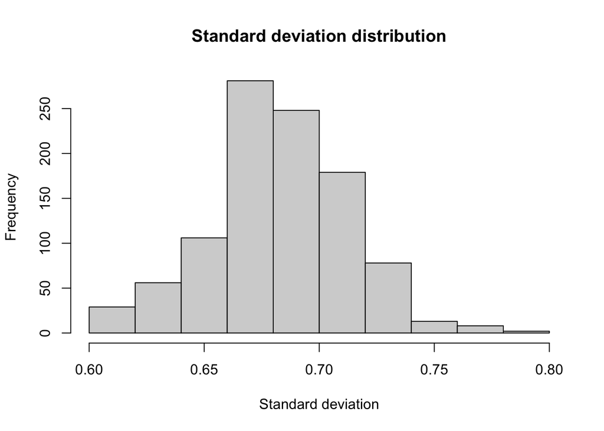

```r
hist(d_MCMC$par3, main="Standard deviation distribution", xlab = "Standard deviation")
```

**Question 7:** Provide the mean and 95% Credible Intervals for each parameter

**Answer 7:**

```r
#soil temperature mean
d_MCMC %>% summarize(mean(par1)) %>% as.vector()
```

```
$`mean(par1)`
[1] 6.760249
```

```r
#soil moisture mean
d_MCMC %>% summarize(mean(par2)) %>% as.vector()
```

```
$`mean(par2)`
[1] 2.360335
```

```r
#standard deviation mean
d_MCMC %>% summarize(mean(par3)) %>% as.vector()
```

```
$`mean(par3)`
[1] 0.6832859
```

```r
#quantile for soil temperature
quantile(x=d_MCMC$par1, probs=c(0.025, 0.975))
```

```
    2.5%    97.5%
6.582072 6.962376
```

```r
#quantile for soil moisture
quantile(x=d_MCMC$par2, probs=c(0.025, 0.975))
```

```
    2.5%    97.5%
2.261910 2.466085
```

```r
#quantile for standard deviation
quantile(x=d_MCMC$par3, probs=c(0.025, 0.975))
```

```
     2.5%     97.5%
0.6169126 0.7393792
```

**Question 8:** Random select 1000 values from the parameters in your posterior distribution. Show the randomly selected values for each parameter as a histogram.

**Answer 8:**

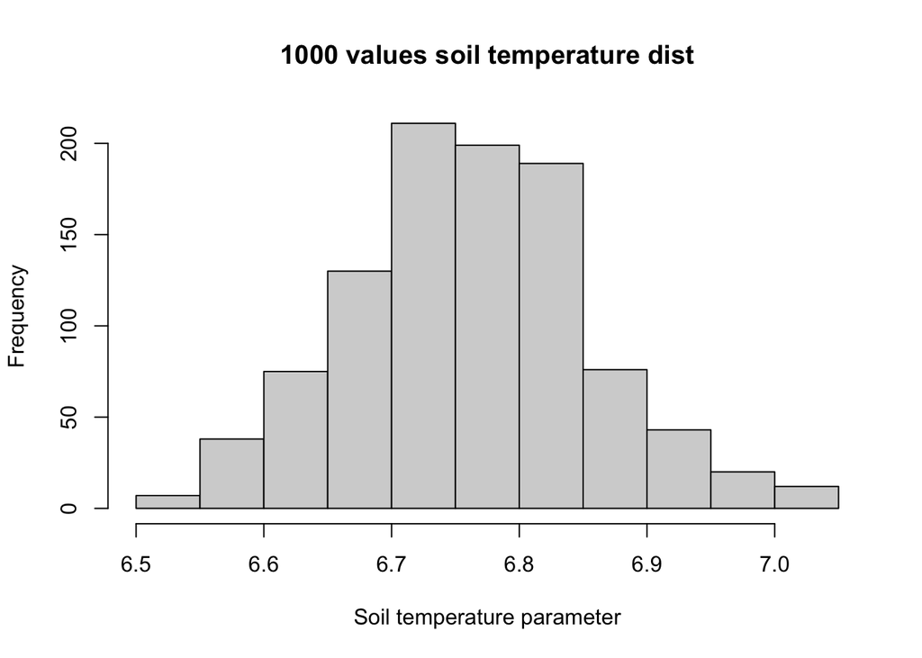

```r
index<-sample(nburn:num_iter, 1000, replace=T)
temp1000<-pars[1, index]
moist1000<-pars[2, index]
sd1000<-pars[3, index]

hist(temp1000, main="1000 values soil temperature dist", xlab = "Soil temperature parameter")
```

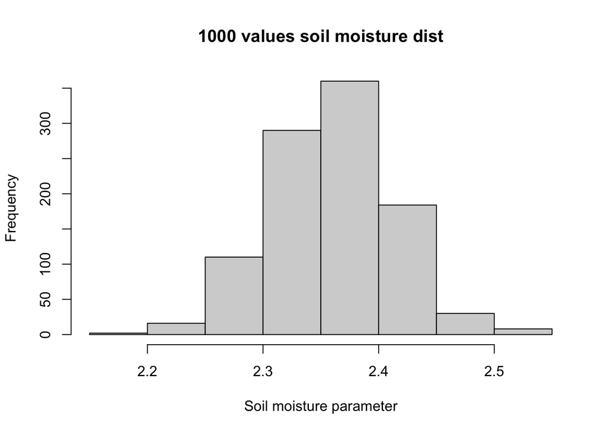

```r
hist(moist1000, main="1000 values soil moisture dist", xlab = "Soil moisture parameter")
```

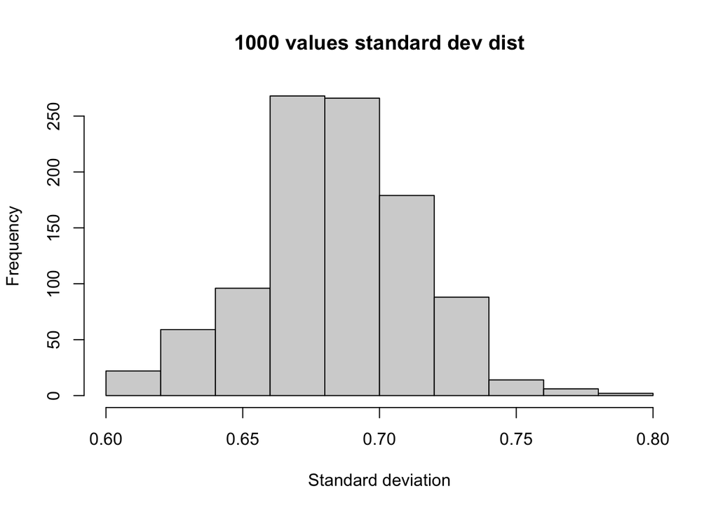

```r
hist(sd1000, main="1000 values standard dev dist", xlab = "Standard deviation")
```

**Question 9:** Use the samples from Question 8 to generate posterior predictions of soil respiration at the observed temperature values (i.e., the same temperature data used in your model fit). Provide a plot with temperature on the x-axis and respiration on the y-axis. The plot should have the mean and 95% predictive uncertainty bounds (i.e., include uncertainty in parameters and in the data model)

**Answer 9:**

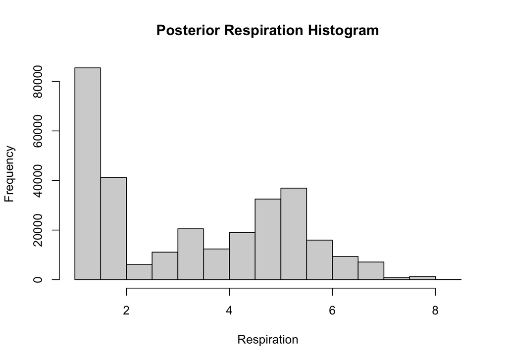

```r
output<-NULL
output_test<-NULL
for(t in 2:length(df$doy)){
  for(m in 1:1000) {
    pred[m] <- temp1000[m] * moist1000[m]**((x[t]-20)/10)

  }
  output<-tibble(pred.resp= pred,
                 obs.temp=x[t],
                 time=t,
                 par1=temp1000,
                 par2=moist1000)

  output_test<-rbind(output_test, output)
}

lowquant<-NULL
upquant<-NULL
mean.resp<-NULL
for(f in 2:length(df$doy)){
  chosen<-output_test %>% filter(time==f)
  mean.resp[f]<-chosen %>% filter(time==f) %>% summarize(mean(pred.resp)) %>% as.numeric()
    lowquant[f]<-quantile(chosen$pred.resp, probs=c(0.025))
    upquant[f]<-quantile(chosen$pred.resp, probs=c(0.975))
}

dftobind<-tibble(mean.resp=mean.resp,
                 lowquant=lowquant,
                 upquant=upquant,
                    time=1:length(df$doy))

finalout<-left_join(output_test, dftobind, by='time')

#Distribution of predicted respiration values
hist(finalout$pred.resp,main="Posterior Respiration Histogram", xlab = "Respiration")
```

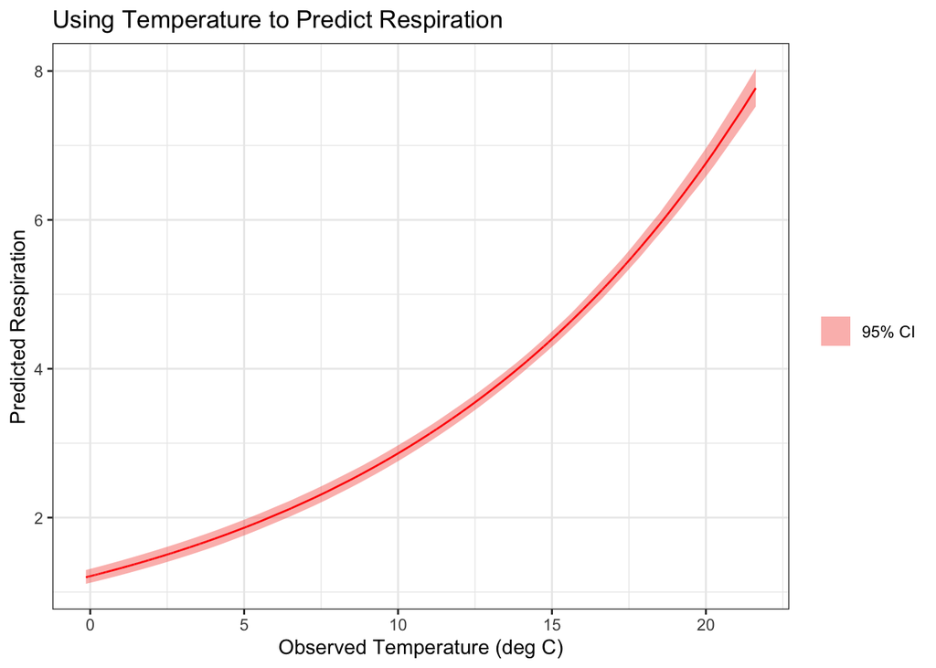

```r
#plot of temperature and mean respiration with 95% certainty interval
ggplot(data=finalout) +
  geom_ribbon(aes(ymin = lowquant, ymax = upquant, x=obs.temp, fill="red"), alpha = 0.5, show.legend = T) +
  geom_line(aes(y = mean.resp, x=obs.temp), color="red") +
  # geom_point(aes(x = obs.temp, y = pred.resp), color = "blue", size=0.2, alpha=0.1) +
  theme_bw()+
  ylab("Predicted Respiration")+
  xlab("Observed Temperature (deg C)")+
  ggtitle("Using Temperature to Predict Respiration")+
  theme(legend.title=element_blank())+
  scale_fill_discrete(labels="95% CI")
```

```r
#uncomment to save save posteriors
#write_csv(finalout, "respiration.posteriors.csv")
```